# Lecture 05

2026-04-14

# Welcome Back

## Anonymous Activity 1

### QR Code (it’s getting better)

This is anonymous & optional, but helpful to Stats 20,

[figure not shown]

or here is a [direct link](https://www.menti.com/bl85t9eie94a)

## Answers to questions I have received

- tables
- load()
- save()
- Where?
- Example
- Later
- DataCamp
- If you like pretty tables, there are several libraries that you can utilize.
- [kableExtra](https://cran.r-project.org/web/packages/kableExtra/vignettes/awesome_table_in_html.html)
- [gt](https://gt.rstudio.com/) written by the folks at RStudio
- [dt](https://rstudio.github.io/DT/) typically use with dashboards or online
- You can make reasonably nice tables in Quarto
- Yes, you should know how to load a saved R workspace and you should probably learn how to save one though I won’t test you on it (others might):

```r
## Assumes you have a .RData file with this name in your project folder (AKA current working directory)

load("spotify_songs.RData")
ls() # a check to make sure something loaded
```

```
[1] "spotify_songs"
```

- The R objects stored inside of a saved R workspace have no necessary relationship to the external file name of the workspace. Hence ls() to check.
- Yes, you can save a workspace, if you want to be lazy, just issue a `save.image()` at end of your R session and it will save everything you created, the good and the not so good:

```markdown
save.image()
```

- IMO is better to have a more controlled/mindful save()

```markdown
x <- runif(20)
y <- c(1, TRUE, "FALSE")
save(x, y, file = "junk.RData")
```

- Where R objects are saved can be confusing and is valuable to understand if you plan to perform more computation in an upper division course (e.g., 102 series) in the future.

```r
getwd() # what is the current working directory/folder
```

```
[1] "/Users/vivian/Desktop/SP26Stats20/website/lectures/Lecture0506"
```

```r
list.files() # what is in the working directory
```

```
[1] "_extensions"          "images"               "Lecture05.qmd"
[4] "Lecture05.rmarkdown"  "Lecture06.qmd"        "my_folder"
[7] "spotify_songs.RData"  "starwars.RData"       "state_database.RData"
```

- What is important is to know how to tell R how to find something, like a data file or an image file. Or to validate that a file is there. Or to create one if its not.
- I don’t ask you to do that, but if you want practice, create a sub-directory or a subfolder on your computer drive and put something in it, like an image file or an R Data file
- Then try to read it into R
- How do we create a folder from within R and why would we do this?
- You could store output in an orderly manner knowing how to do this

```r
x <- seq(from = 1, to = 1000, by = 2)
y <- rnorm(n = 160, mean = 120, sd = 15)

dir.create("my_folder") # if it already exists it will throw a FALSE but not an error
save(x, y, file = "my_folder/xy.RData") # Save the file "xy.RData" in the "my_folder"
```

- For those of you who are just dying in here because I move too slow, eventually I will want you to be able to read and understand this also possibly write something similar (esp. for 102):

```r
# Check if the folder "my_folder" exists, if not, create it.
if (!dir.exists("my_folder")) {
  dir.create("my_folder")
}
# Save the file "xy.RData" in the "my_folder" if it does not exist
# otherwise (else) tell me it is already there.
if (!file.exists("my_folder/xy.RData")) {
  save(x, y, file = "my_folder/xy.RData")
  cat("The file was created and saved successfully.\n")
} else {
  cat("The file already exists.\n")
}
```

```
The file already exists.
```

```r
## prove it to me
{cat("These are the files in the folder:\n")
files_in_folder <- list.files("my_folder")
files_in_folder}
```

```
These are the files in the folder:
```

```
[1] "xy.RData"
```

- We will visit flow control then functions after we look at data and visualization
- I don’t assign homework, I think projects are more realistic
- But DataCamp is there to give you extra practice. I curate their “chapters” as best as I can to match the subjects in lecture
- DataCamp is structured to let you do things at your own pace
- So I just need to see that you attempted the assignment
- You do not need to complete everything and you do not need to get it 100% correct
- The deadlines are there so you can pace yourselves, I will only calculate completion at the end of the quarter
- The Intro to Stats module is there for the kind students who let me know that they have forgotten a lot of their intro stats training. I appreciate honesty.

# Closing thought from last time

## What is a low level language? Assembly v R

- Assembly invented in 1947, R 1993, fyi: Python 1989

```
.model small
.stack 100h

.data
a dw 2
b dw 5

.code
main proc
    mov ax, @data
    mov ds, ax

    mov ax, a
    mov bx, b
    add ax, bx

    add al, 30h
    mov dl, al
    mov ah, 02h
    int 21h

    mov ah, 4Ch
    int 21h
main endp
end main
```

- In R

```
a <- 2
b <- 5

a + b
```

- Extra (binary, the OG), 2 and 5, represented, not added yet

```
0000000000000010
0000000000000101
```

- And the representation for 7 may make sense to you

```
0000000000000111
```

## For your consideration

- In assembly, we must tell the computer every tiny step. Assembly required humans to think/communicate like machines.
- In R, Python, and other modern languages, we write what we want in a compact and more natural form
- Programming languages evolved to let humans think less about machine details and more about ideas, data, and problems.
- LLMs are part of the same long arc of evolution. They allow us to express intent in ordinary language. So “please add 2 and 5” as in the previous slide
- Assembly -> C -> Python -> LLMs(?) older languages were not completely replaced – but their application may be narrower

## A final thought on this

- If you ask an LLM (I asked ChatGPT) what languages it rests upon, perhaps this answer is not too surprising:

```
Human language
   ↓
Python (or similar high-level language)
   ↓
C / C++ (fast execution)
   ↓
Assembly
   ↓
Machine code (binary)
```

- it relies on many different tools for many different applications

## Attendance Opportunity

### Activity #2: Please Greet Your Neighbor(s)

- You are experts at greeting your neighbors now.
- You need at least one different neighbor each week for your attendance credit (only one photo required)
- You cannot receive credit if it’s only you in the photo
- [Social Connection has value](https://www.cdc.gov/social-connectedness/about/index.html#:~:text=Positive%20health%20benefits,in%20public%20places%2C%20such%20as:)
- Meet a new classmate, take a photograph.

# Data Week

## What are they looking for?

- [Red Bull Internship](https://jobs.redbull.com/us-en/east-hanover-2026-internship-spring-data-science-ref29674o)
- [Booz Allen Hamilton](https://careers.boozallen.com/teams/JobDetail?jobId=122342)
- [TikTok](https://lifeattiktok.com/search/7533019095227648263)
- [First American (Title)](https://careers.firstam.com/job/santa-ana/data-scientist-intern-remote/39054/91871549312)
- [Petco](https://careers.petco.com/en/job/san-diego/petco-love-data-analyst/47428/93323382352)

## Depends, but

- Can you work with real data (messy, large, multiple sources)
- Can you write a script (or more advanced, model outcomes)
- Can you communicate your findings (present, tell a story, connect)
- Do you have the an understanding of the business context?

## What to focus on this week

- Working with real data
- Knowing how to “data wrangle” – basic making messy data suitable for analysis
  - Handling missing values
  - Converting data types
  - Reshaping data (going from wide format to long and back)
  - Joining data
  - Cleaning text or categories

## Recall: Workflow (in research)

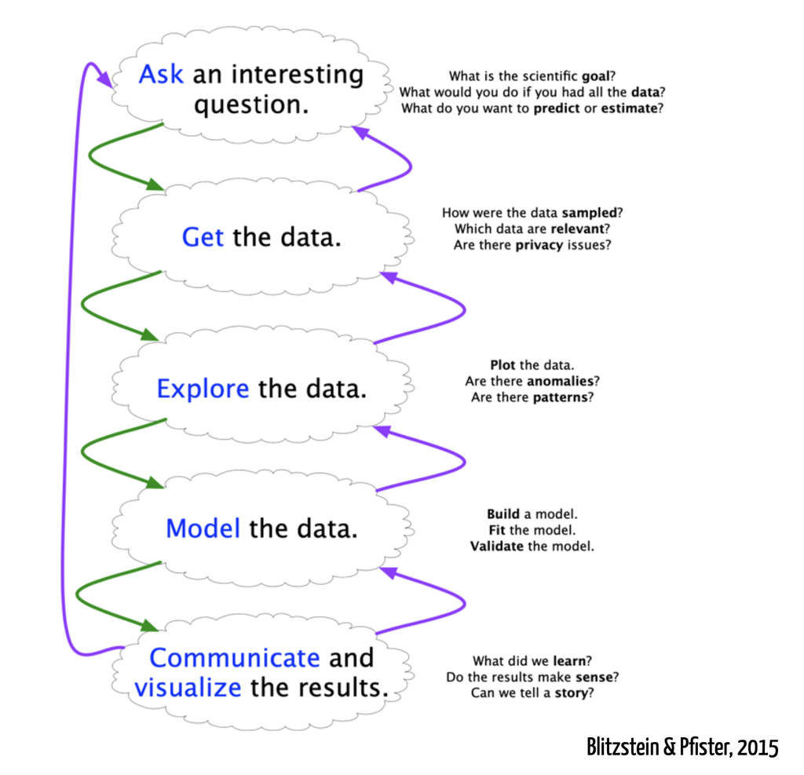

A Data Science Workflow

## Recall: Workflow (in workplaces)

[figure not shown]

From Google

## It’s only data…

- The content of all four of these are exactly the same (your Project 1 dataset), the formatting is different:

[comma separated values (.csv)](https://raw.githubusercontent.com/lewv/data-for-example/main/pokemon.csv)

[tab separated values (.tsv)](https://raw.githubusercontent.com/lewv/data-for-example/main/pokemon.tsv)

[white space delimited values (.txt)](https://raw.githubusercontent.com/lewv/data-for-example/main/pokemon.txt)

[json example](https://raw.githubusercontent.com/lewv/data-for-example/main/pokemon.json) – extra

## Read into R

- We do not need to load any special libraries/install packages for the first three. We will read the fourth one later.
- We will use base R (core R, what is available at installation) and the functions `read.csv()`, `read.delim()`, and `read.table()`
- These are relatively simple to read because they are DELIMITED (have a separator) between variables (AKA fields)
- There is a logical workflow (1) need to know their location (2) need a function to convert the data into an R data frame (3A) need to check my work - did they get read (3B) are all 3 the same?

# Activity 3 - Running an R Script

## Code

- Please turn to RStudio
- We are going to work through an R script named **remote_delimited.R** you can find it in Week 3 under Tuesday
- Read data off the web and save data to your to your drive
- If you don’t have RStudio today, you can copy and paste most of this to Web-R
- But it is nice to have a friend so you don’t get lost because the Web-R will have some problems.

## Saving your workspace

- You should know how to save your work, `save()` works just fine, here is a multiple object example:

```r
save(pokemon_data_csv, pokemon_data_tsv, pokemon_data_txt, file = "all_my_pokemon.RData")
```

- When you `load("all_my_pokemon.RData")` in another session, all 3 data frames will be restored to your global environment.

## Excel and Others

- There are special libraries that we can use to read Excel files (later). You could also convert your Excel file to .csv for example
- But we can read Google sheets using R as long as we own them or have been given permission to read them:

```r
in_n_out_locs <- read.csv("https://docs.google.com/spreadsheets/d/1eTkMGK4Bsab5cN-UtQgqdosGDlLPtWj7UtC4F5BsQ8E/export?format=csv&gid=50145464")
in_n_out_latlon <- read.csv("https://docs.google.com/spreadsheets/d/1eTkMGK4Bsab5cN-UtQgqdosGDlLPtWj7UtC4F5BsQ8E/export?format=csv&gid=1610759547")

names(in_n_out_locs)
```

```
[1] "name"    "address" "city"    "state"   "zip"
```

```r
names(in_n_out_latlon)
```

```
[1] "name"      "zip"       "latitude"  "longitude"
```

## Still Others

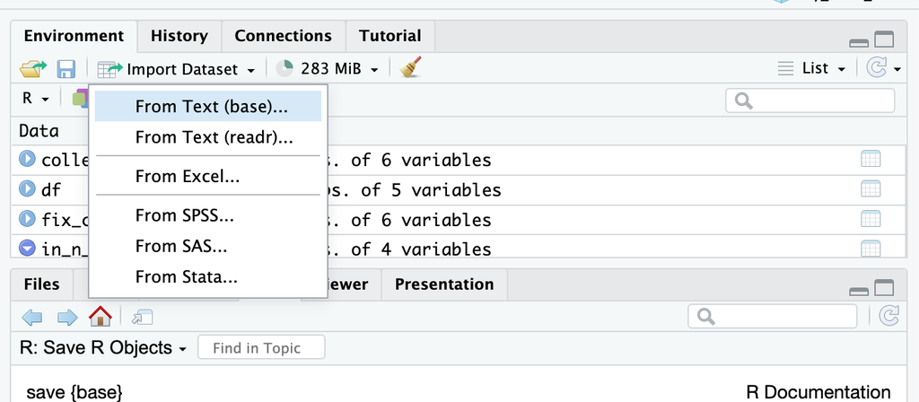

some competitors

## Who are they?

- These are specialized statistical packages
- They almost all have “bridges” to Python and/or R.
- SAS 1976 (pharma); SPSS 1968 (psychologists); Stata 1985 (economists)
- I won’t ask you about these. I am OK if you point and click your way to a solution or ask AI.

## What happens when data is not perfectly read?

- It is getting more difficult to show you an example as computers don’t usually make mistakes in collecting/constructing data, but people do:

```r
colleges <- read.delim("https://raw.githubusercontent.com/lewv/data-for-example/refs/heads/main/colleges.txt")
colleges
```

```
         Name Quality Academics Sports Cost Overall
1   Princeton       1         3     11   75       1
2         UNC      46        22     10   31       2
3    Stanford       4         5      1  110       3
4        Yale      14         4      5  100       4
5    Virginia      24        30     29   41       5
6    Williams       2        25     19   80       6
7    Michigan      38        24      9   64       7
8   NotreDame       6        31     32   73       8
9  California      50        15     20   61       9
10    Harvard      12         1     39   98      10
11       UCLA      67        20      2   66      11
12   Columbia      33         9     35   79      12
13       USNA      28        88     45    1      13
14       Duke       5        10     48  104      14
15    Amherst       3        28     50   88      15
16      Texas     106        36     12   18      16
17    Florida      71        38     59    7      17
18       Rice      19        11     89   58      18
19  Dartmouth      11        14     52  103      19
20 Middlebury      21        40     15  108      20
21  NewJersey      44       102     14   25      21
22  PennState      69        56     17   44      22
23   Oklahoma      77        86     22    9      23
24    CalTech      NA        17      6  106      65
25         23      NA        NA     NA   NA      NA
26   Maryland      91        46     28   34      25
27        LSU      75        99     13   12      25
```

- Notice no warning. You should always check a data read.

## What is NA in R?

- NA represents unknown or unavailable data
- It is NOT positive
- It is NOT negative
- It is not zero
- not a number at all

> There should be a value here, but we don’t know what it is.

## What does NA mean to R?

```r
5 + NA # NA
```

```
[1] NA
```

```r
NA == 5 # NA
```

```
[1] NA
```

```r
NA == NA # NA
```

```
[1] NA
```

```r
is.na(NA) # TRUE
```

```
[1] TRUE
```

- By not substituting a value, R lets the user decide how to address NA

## What happens when data is not perfect?

- With a tiny dataset like this, it’s easy to find the problem

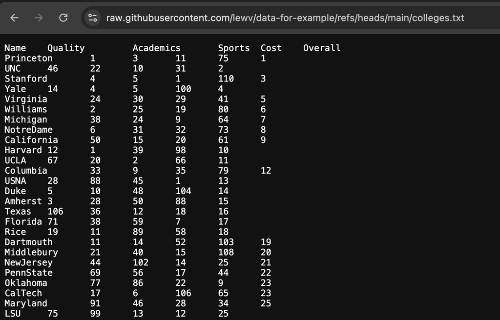

dataset with mistakes

## What happens when data is not perfect (cont’d)

- apply correction, typically by substitution (but could drop the observation)
- but usually by filtering/subsetting (next lecture) first though locate the error
- in our tiny example, we are going the correct the two rows that are incorrect
- we haven’t gotten to all of the details here, but we will

```r
colleges[24, 2:6] # has a mistake
```

```
   Quality Academics Sports Cost Overall
24      NA        17      6  106      65
```

```r
colleges[24, 2:6] <- c(17, 6, 106, 65, 23) # overwrite
colleges # check
```

```
         Name Quality Academics Sports Cost Overall
1   Princeton       1         3     11   75       1
2         UNC      46        22     10   31       2
3    Stanford       4         5      1  110       3
4        Yale      14         4      5  100       4
5    Virginia      24        30     29   41       5
6    Williams       2        25     19   80       6
7    Michigan      38        24      9   64       7
8   NotreDame       6        31     32   73       8
9  California      50        15     20   61       9
10    Harvard      12         1     39   98      10
11       UCLA      67        20      2   66      11
12   Columbia      33         9     35   79      12
13       USNA      28        88     45    1      13
14       Duke       5        10     48  104      14
15    Amherst       3        28     50   88      15
16      Texas     106        36     12   18      16
17    Florida      71        38     59    7      17
18       Rice      19        11     89   58      18
19  Dartmouth      11        14     52  103      19
20 Middlebury      21        40     15  108      20
21  NewJersey      44       102     14   25      21
22  PennState      69        56     17   44      22
23   Oklahoma      77        86     22    9      23
24    CalTech      17         6    106   65      23
25         23      NA        NA     NA   NA      NA
26   Maryland      91        46     28   34      25
27        LSU      75        99     13   12      25
```

## How do we remove a row (or rows)?

- usually in a larger dataset, we apply a condition
- here, we are just going to drop the one row

```r
fix_colleges <- colleges[-25, ] # copy the original, don't clobber it
fix_colleges # the numbering is off
```

```
         Name Quality Academics Sports Cost Overall
1   Princeton       1         3     11   75       1
2         UNC      46        22     10   31       2
3    Stanford       4         5      1  110       3
4        Yale      14         4      5  100       4
5    Virginia      24        30     29   41       5
6    Williams       2        25     19   80       6
7    Michigan      38        24      9   64       7
8   NotreDame       6        31     32   73       8
9  California      50        15     20   61       9
10    Harvard      12         1     39   98      10
11       UCLA      67        20      2   66      11
12   Columbia      33         9     35   79      12
13       USNA      28        88     45    1      13
14       Duke       5        10     48  104      14
15    Amherst       3        28     50   88      15
16      Texas     106        36     12   18      16
17    Florida      71        38     59    7      17
18       Rice      19        11     89   58      18
19  Dartmouth      11        14     52  103      19
20 Middlebury      21        40     15  108      20
21  NewJersey      44       102     14   25      21
22  PennState      69        56     17   44      22
23   Oklahoma      77        86     22    9      23
24    CalTech      17         6    106   65      23
26   Maryland      91        46     28   34      25
27        LSU      75        99     13   12      25
```

## Renumbering your row names (extra)

- if you must… this is more sequence generating:

```r
rownames(fix_colleges) # we lost row 25
```

```
 [1] "1"  "2"  "3"  "4"  "5"  "6"  "7"  "8"  "9"  "10" "11" "12" "13" "14" "15"
[16] "16" "17" "18" "19" "20" "21" "22" "23" "24" "26" "27"
```

```r
rownames(fix_colleges) <- 1:26 # numeric vector
rownames(fix_colleges) # coerced to character
```

```
 [1] "1"  "2"  "3"  "4"  "5"  "6"  "7"  "8"  "9"  "10" "11" "12" "13" "14" "15"
[16] "16" "17" "18" "19" "20" "21" "22" "23" "24" "25" "26"
```

```r
fix_colleges
```

```
         Name Quality Academics Sports Cost Overall
1   Princeton       1         3     11   75       1
2         UNC      46        22     10   31       2
3    Stanford       4         5      1  110       3
4        Yale      14         4      5  100       4
5    Virginia      24        30     29   41       5
6    Williams       2        25     19   80       6
7    Michigan      38        24      9   64       7
8   NotreDame       6        31     32   73       8
9  California      50        15     20   61       9
10    Harvard      12         1     39   98      10
11       UCLA      67        20      2   66      11
12   Columbia      33         9     35   79      12
13       USNA      28        88     45    1      13
14       Duke       5        10     48  104      14
15    Amherst       3        28     50   88      15
16      Texas     106        36     12   18      16
17    Florida      71        38     59    7      17
18       Rice      19        11     89   58      18
19  Dartmouth      11        14     52  103      19
20 Middlebury      21        40     15  108      20
21  NewJersey      44       102     14   25      21
22  PennState      69        56     17   44      22
23   Oklahoma      77        86     22    9      23
24    CalTech      17         6    106   65      23
25   Maryland      91        46     28   34      25
26        LSU      75        99     13   12      25
```

## Takeaways

- Data can be imperfect; you might not be warned
- There are multiple solutions; weigh the pros and cons
- The corrections gave no feedback; therefore always check your results
- Small datasets like this example are easy; we must be clever about finding mistakes and correcting them in larger ones

# Questions?

## Data is Everywhere

- If you would turn to Week 3 Module, Tuesday
- Kaggle
- UCI Machine Learning Repository
- etc.

## What is JSON?

- JSON stands for JavaScript Object Notation
- JSON is a data-interchange format
- JSON is language independent text so it can be used by different software
- JSON is “human readable” and easy to understand
- JSON structure is (or can be) hierarchical (values within values)
- JSON is short and easy to write
- JSON syntax is a subset of the JavaScript syntax.
- The file type for JSON files is “.json”

## Simple Example

- This is not meant to be definitive exploration of json files.
- I like the jsonlite package mostly because I know the maintainer personally.
- First, install then activate the jsonlite library. `library(jsonlite)` and you will need `library(httr)` for my second example to work
- But try the first example with a fromJSON before moving to more complex forms

## Code & Result

```r
library(jsonlite)

url_films <- "https://gist.githubusercontent.com/saniyusuf/406b843afdfb9c6a86e25753fe2761f4/raw/075b6aaba5ee43554ecd55006e5d080a8acf08fe/Film.JSON"

films <- fromJSON(url_films)

head(films)
```

```
                    Title Year Rated    Released Runtime
1                  Avatar 2009 PG-13 18 Dec 2009 162 min
2             I Am Legend 2007 PG-13 14 Dec 2007 101 min
3                     300 2006     R 09 Mar 2007 117 min
4            The Avengers 2012 PG-13 04 May 2012 143 min
5 The Wolf of Wall Street 2013     R 25 Dec 2013 180 min
6            Interstellar 2014 PG-13 07 Nov 2014 169 min
                       Genre          Director
1 Action, Adventure, Fantasy     James Cameron
2      Drama, Horror, Sci-Fi  Francis Lawrence
3     Action, Drama, Fantasy       Zack Snyder
4   Action, Sci-Fi, Thriller       Joss Whedon
5   Biography, Comedy, Crime   Martin Scorsese
6   Adventure, Drama, Sci-Fi Christopher Nolan
                                                                                                                                        Writer
```

[output cut: 62 more lines]

## Practical Example

- [SF Film Locations](https://data.sfgov.org/Culture-and-Recreation/Film-Locations-in-San-Francisco/yitu-d5am/about_data)

```r
library(httr)  # need this to get the URL
library(jsonlite) # need this to convert the json to a data frame

url_sf <- "https://data.sfgov.org/resource/yitu-d5am.json"

# first, make sure the URL is valid
check <- GET(url_sf, verbose())
status_code(check) # should return 200
```

```
[1] 200
```

```r
# we see there are limits imposed, only 1000
locations_check <- fromJSON(content(check, "text"), flatten = TRUE)
```

## Result

```r
head(locations_check)
```

```
                           title release_year             locations
1                           Milk         2008     El Camino Del Mar
2                Chance Season 2         2017            Coit Tower
3                      Red Widow         2013 Mason & Sacramento St
4 A Taiwanese Tale of Two Cities         2018                Pier 5
5                      Americana         2015   Palace of Fine Arts
6             Desperate Measures         1998                  <NA>
         production_company                         distributor
1            Focus Features                      Focus Features
2      TVM Productions Inc.                                Hulu
3                Beyond Pix American Broadcasting Company (ABC)
4 Envision Productions Inc.                             Netflix
5           Sutro Films LLC                                <NA>
6    Mandalay Entertainment                    TriStar Pictures
          director                                                writer
```

[output cut: 41 more lines]

## Interpretation

- GET() sends an HTTP request
- We receive a response object with status code (200 - understood, 404 - not found, etc.) headers and content (the JSON)
- fromJSON() converts the response to a data frame
- They store the larger data, we access it in a legal orderly fashion.

## Bigger Challenges - Multiple files

- [Yelp Open Data](https://business.yelp.com/data/resources/open-dataset/)
- [LA City Parking Meters](https://data.lacity.org/Transportation/LADOT-Parking-Meter-Occupancy/e7h6-4a3e/about_data)
- [and their locations](https://data.lacity.org/Transportation/LADOT-Metered-Parking-Inventory-Policies/s49e-q6j2/about_data)
- but really, for next time

## For your consideration

- This is a simplified version pre-pandemic

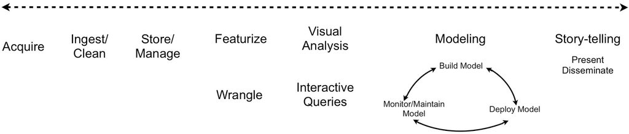

Old Data Science Workflow

## Takeaways

- Rectangular format of csv, tsv, txt, Excel is older
- There are even older forms of data that are seen in specific disciplines
- JSON is transitional and is used in many places
- Newer formats (e.g., parquet, arrow, etc.) exist for size & speed and for non-rectangular forms (later)
- But data is just data, don’t let the different formats scare/stop you